# Autor: Luis Alberto Marín Soto

# **Machine Learning**

Una vez realizada el tratamiento de los datos, se probarán algunos algoritmos de *Machine Learning* buscando cuál es el que mejor se ajusta a estos. En esta parte, trabajaremos con datos antes del tratamiento (pre_tratamiento) y después del tratamiento (post-tratamiento).

```python
# ———Importación de algoritmo de Machine Learning y algunas métricas———
from sklearn.model_selection import train_test_split          # División del dataset en trainset y testset
from sklearn.model_selection import cross_val_score           # Métrica de validacion: Validación Cruzada
from sklearn.linear_model import LinearRegression             # Regresión lineal
from sklearn.tree import DecisionTreeRegressor                # Árbol de Decisión tipo Regresión
from sklearn.ensemble import RandomForestRegressor            # Bosque Aleatorio tipo Regresión
from sklearn.svm import SVR                                   # Maquina de Soporte Vectorial tipo Regresión
from sklearn.metrics import root_mean_squared_error, r2_score # Métricas de evaluación: Raiz del Error Cuadrático Medio y R-cuadrado
from sklearn.preprocessing import StandardScaler              # Escalado/Estandarización de los datos
```

En esta oportunidad, buscaremos predecir a qué longitud se llevará a cabo el sismo en función de las variables creadas y las que estaban por defecto en el dataset original.

```python
# ———Generación de trainset y testset———
X = data_cambiada[['LATITUD','MAGNITUD','HORA_HECHO','PROFUNDIDAD','DIAS_TRANSCURRIDOS']] # Variables independientes
y = data_cambiada['LONGITUD']                                                             # Variables dependientes

X_train, X_test, y_train, y_test = train_test_split(X, y, test_size = 0.2, random_state = 123)
```

```python
# ———Creación de una función que devuelva un dataframe con todos los resultados de todos los modelos con parámetros ya establecidos———
def modelo_global(X_train, X_test, y_train, y_test):
  # ———Modelos a utilizar———
  # Modelo Lineal
  modelo_lineal = LinearRegression()
  modelo_lineal.fit(X_train, y_train)
  y_pred_lineal = modelo_lineal.predict(X_test)
  # Modelo DecisionTree
  modelo_dt = DecisionTreeRegressor(max_depth=5)
  modelo_dt.fit(X_train, y_train)
  y_pred_dt = modelo_dt.predict(X_test)
  # Modelo RandomForest
  modelo_rf = RandomForestRegressor(n_estimators=100, random_state=123)
  modelo_rf.fit(X_train, y_train)
  y_pred_rf = modelo_rf.predict(X_test)
  # Modelo SupportVectorialMachine
  modelo_svm = SVR(kernel='rbf')
  modelo_svm.fit(X_train, y_train)
  y_pred_svm = modelo_svm.predict(X_test)
  # ———Métricas de evaluación———
  r2_lineal = f'{r2_score(y_test, y_pred_lineal)*100:.3f}%'
  r2_dt = f'{r2_score(y_test, y_pred_dt)*100:.3f}%'
  r2_rf = f'{r2_score(y_test, y_pred_rf)*100:.3f}%'
  r2_svm = f'{r2_score(y_test, y_pred_svm)*100:.3f}%'
  rmse_lineal = root_mean_squared_error(y_test, y_pred_lineal)
  rmse_dt = root_mean_squared_error(y_test, y_pred_dt)
  rmse_rf = root_mean_squared_error(y_test, y_pred_rf)
  rmse_svm = root_mean_squared_error(y_test, y_pred_svm)
  # ———Dataframe de resultados———
  Resultados = pd.DataFrame(
      data = {'Modelo': ['Lineal','DecisionTree','RandomForest','SupportVectorialMachine'],
              'R-cuadrado (R2)':[r2_lineal,r2_dt,r2_rf,r2_svm],
              'Raiz del Error Cuadrático Medio (RMSE)':[rmse_lineal,rmse_dt,rmse_rf,rmse_svm]},
  )
  return Resultados
```

```python
# ———Creación de una función para seleccionar un modelo con parámetros elegidos por el usuario———
Modelos = {'ln':'Lineal','dt':'DecisionTree','rf':'RandomForest','svm':'SupportVectorialMachine'}
Longitud = {'ln': 35, 'dt': 41, 'rf': 41, 'svm': 52}
def seleccion_modelo(X, y):
  modelo = input('Ingrese el modelo que desea utilizar entre ln (Lineal), dt (DecisionTree), rf (RandomForest) ó svm (SupportVectorialMachine): ')
  if modelo not in Modelos:
    print('No se eligió ningún modelo')
    return
  estandarizado = False  # Variable para controlar si ya se estandarizó
  estandarizar = str(input('¿Desea estandarizar las variables desde el inicio? (Yes/No):')).strip().lower()   # Preguntar si se quiere estandarizar al inicio
  if estandarizar == 'yes':
    scaler = StandardScaler()
    X = scaler.fit_transform(X)
    y = scaler.fit_transform(y.values.reshape(-1, 1)).ravel()
    estandarizado = True  # Datos estandarizados
    # Dividir los datos al inicio
  X_train, X_test, y_train, y_test = train_test_split(X, y, test_size=0.4, random_state=123)
  if modelo == 'ln':
    model = LinearRegression()
    model.fit(X_train, y_train)
    y_pred = model.predict(X_test)
  elif modelo == 'dt':
    while True:
      try:
        profundidad = int(input('Ingrese nivel de profundidad (un número entero): '))
        if profundidad <= 0:
          print('La profundidad debe ser un número mayor que 0.')
        else:
          break
      except ValueError:
        print('Por favor, ingrese un valor entero válido para la profundidad.')
    model = DecisionTreeRegressor(max_depth=profundidad)
    model.fit(X_train, y_train)
    y_pred = model.predict(X_test)
  elif modelo == 'rf':
    while True:
      try:
        arboles = int(input('Ingrese el número de arboles (número entero): '))
        if arboles <=0:
          print('El número de arboles debe ser un número mayor que 0.')
        else:
          break
      except ValueError:
        print('Por favor, ingrese un valor entero válido para el número de arboles.')
    model = RandomForestRegressor(n_estimators = arboles, random_state = 123)
    model.fit(X_train, y_train)
    y_pred = model.predict(X_test)
  elif modelo == 'svm':
    if not estandarizado:  # Obligar a estandarizar si no se hizo antes
      print("Para SVM, es obligatorio estandarizar los datos.")
      scaler = StandardScaler()
      X = scaler.fit_transform(X)
      y = scaler.fit_transform(y.values.reshape(-1, 1)).ravel()
      X_train, X_test, y_train, y_test = train_test_split(X, y, test_size=0.4, random_state=123)
    while True:
      try:
        tipo = str(input('Elija tipo de kernel (linear, rbf, poly, sigmoid): ')).strip().lower()
        if tipo not in ['linear', 'rbf', 'poly', 'sigmoid']:
         print('Elija uno de los kernels indicados.')
        else:
         break
      except ValueError:
          print('Por favor, ingrese un valor válido.')
    model = SVR(kernel=tipo)
    model.fit(X_train, y_train)
    y_pred = model.predict(X_test)

  print(f'======Modelo {Modelos[modelo]}: Métricas======')
  print(f'R-cuadrado (R2): {r2_score(y_test, y_pred)*100:.3f}%')
  print(f'Raíz del Error Cuadrático Medio (RMSE): {root_mean_squared_error(y_test, y_pred)}')
  print(f'Validación Cruzada: {cross_val_score(model, X_train, y_train, cv = 5)}')
  print(f'Validación Cruzada (Promedio): {cross_val_score(model, X_train, y_train, cv =5).mean():.3f}%')
  print("="*Longitud[modelo])
```

```python
seleccion_modelo(X, y)
```

```
Ingrese el modelo que desea utilizar entre ln (Lineal), dt (DecisionTree), rf (RandomForest) ó svm (SupportVectorialMachine): rf
¿Desea estandarizar las variables desde el inicio? (Yes/No):no
Ingrese el número de arboles (número entero): 150
======Modelo RandomForest: Métricas======
R-cuadrado (R2): 79.327%
Raíz del Error Cuadrático Medio (RMSE): 1.4169172626275703
Validación Cruzada: [0.7705865  0.78322161 0.77474997 0.77359684 0.78818866]
Validación Cruzada (Promedio): 0.778%
=========================================
```

```python
modelo_global(X_train, X_test, y_train, y_test)
```

|  | Modelo | R-cuadrado (R2) | Raiz del Error Cuadrático Medio (RMSE) |
| --- | --- | --- | --- |
| 0 | Lineal | 71.168% | 1.656065 |
| 1 | DecisionTree | 76.938% | 1.481131 |
| 2 | RandomForest | 78.587% | 1.427193 |
| 3 | SupportVectorialMachine | 72.462% | 1.618479 |

**Conclusión**: En general, los R2 son muy bajos. Intentemos estandarizando variables para ver que tanto serán afectados estos resultado

## **Escalado/Estandarización de los datos**

```python
scaler = StandardScaler()
X_scal = scaler.fit_transform(X)
y_scal = scaler.fit_transform(y.values.reshape(-1, 1)).ravel()

Xs_train, Xs_test, ys_train, ys_test = train_test_split(X_scal, y_scal, test_size = 0.2, random_state = 123)
```

```python
# ———Resultados usando la data ya estandarizada———
modelo_global(Xs_train, Xs_test, ys_train, ys_test)
```

|  | Modelo | R-cuadrado (R2) | Raiz del Error Cuadrático Medio (RMSE) |
| --- | --- | --- | --- |
| 0 | Lineal | 71.168% | 0.534924 |
| 1 | DecisionTree | 76.943% | 0.478362 |
| 2 | RandomForest | 78.548% | 0.461417 |
| 3 | SupportVectorialMachine | 76.373% | 0.484242 |

# **Post-tratamiento de los datos**

En este apartado, se observará cómo varían los resultados de las métricas utilizadas después del tratamiento de los datos mediante la manipulación de *outliers*.

```python
# ———Definimos una función que contenga la función "modelo_global"———
def train_test(X, y):
  X_train, X_test, y_train, y_test = train_test_split(X, y, test_size = 0.4, random_state = 123)
  result = modelo_global(X_train, X_test, y_train, y_test)
  return result
```

```python
# ———Definimos una función para que genere una matriz de correlación———
def matriz_correlacion(df):
  matriz_corr = df.corr()
  sns.heatmap(matriz_corr, annot=True, cmap='coolwarm')
  plt.title('Matriz de correlación')
  plt.show()
```

### Tratamiento de *outliers*

#### 1) Eliminación de *outliers*

La eliminación de *outliers* (valores atípicos) consiste en identificar y remover observaciones en un conjunto de datos que son extremadamente altas, bajas o inusuales en comparación con el resto de los datos. Este proceso busca mejorar el análisis estadístico y evitar que los valores extremos sesguen las conclusiones o modelos.

```python
Q1 = X.quantile(0.25)
Q3 = X.quantile(0.75)
IQR = Q3 - Q1
X_cleaned1 = X[~((X < (Q1 - 1.5 * IQR)) | (X > (Q3 + 1.5 * IQR))).any(axis=1)]
y_cleaned1 = y.loc[X_cleaned1.index]
```

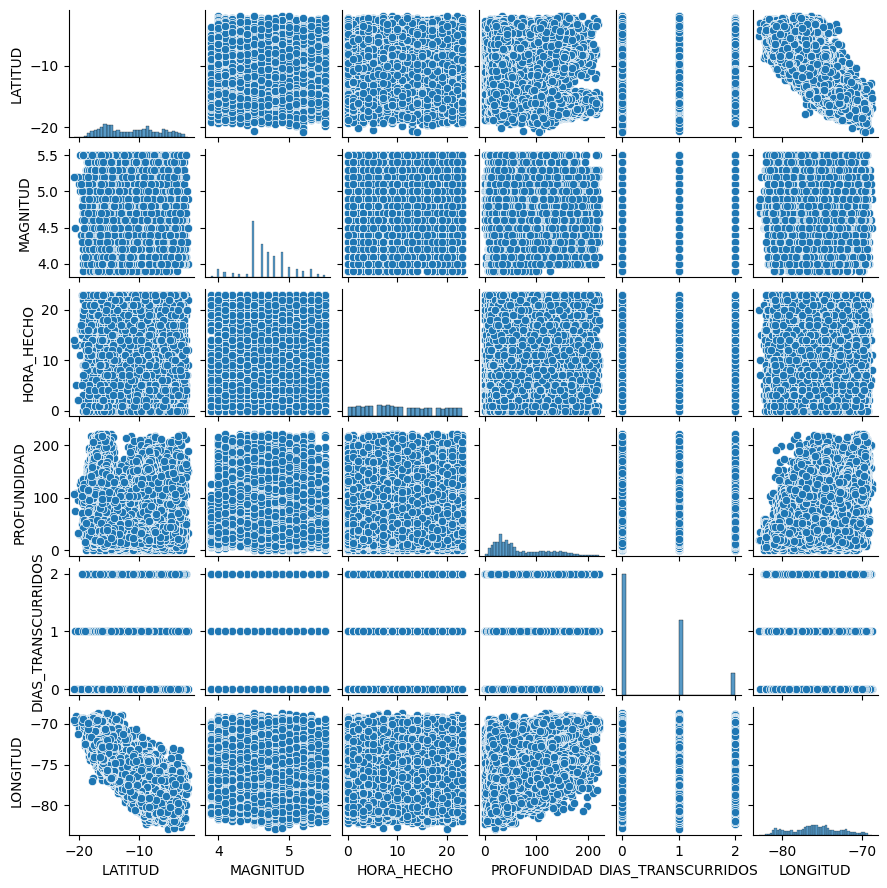

```python
data_cleaned1 = pd.merge(X_cleaned1, y_cleaned1, left_index=True, right_index=True, how='inner')
sns.pairplot(data_cleaned1, height = 1.5)
```

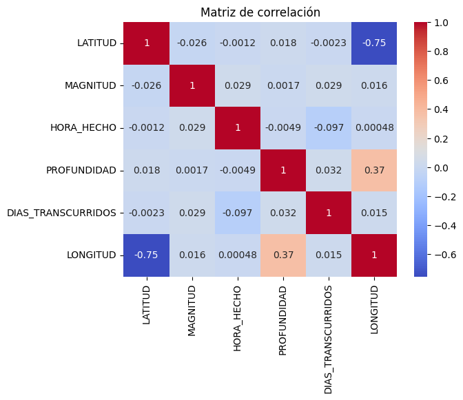

```python
matriz_correlacion(data_cleaned1)
```

```python
train_test(X_cleaned1, y_cleaned1)
```

|  | Modelo | R-cuadrado (R2) | Raiz del Error Cuadrático Medio (RMSE) |
| --- | --- | --- | --- |
| 0 | Lineal | 72.214% | 1.600490 |
| 1 | DecisionTree | 76.674% | 1.466420 |
| 2 | RandomForest | 77.221% | 1.449117 |
| 3 | SupportVectorialMachine | 71.972% | 1.607441 |

#### 2) Winsorización

La winsorización es una técnica estadística utilizada para manejar valores atípicos en un conjunto de datos. En lugar de eliminarlos, estos valores extremos se limitan a un rango definido mediante percentiles. Es una forma de reducir el impacto de los valores atípicos sin perder datos.

```python
from scipy.stats.mstats import winsorize
X_winsorized = X.apply(lambda col: winsorize(col, limits=(0.01, 0.01)))
```

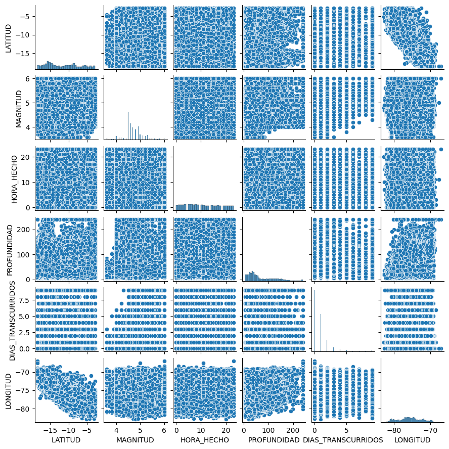

```python
data_winsorized = pd.merge(X_winsorized, y, left_index = True, right_index = True, how = 'inner')
sns.pairplot(data_winsorized, height = 1.5)
```

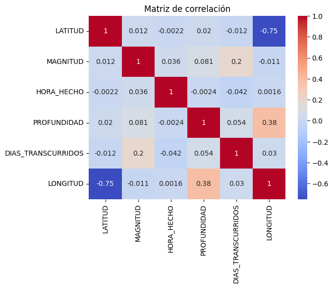

```python
matriz_correlacion(data_winsorized)
```

```python
train_test(X_winsorized, y)
```

|  | Modelo | R-cuadrado (R2) | Raiz del Error Cuadrático Medio (RMSE) |
| --- | --- | --- | --- |
| 0 | Lineal | 72.351% | 1.638641 |
| 1 | DecisionTree | 77.029% | 1.493617 |
| 2 | RandomForest | 79.200% | 1.421285 |
| 3 | SupportVectorialMachine | 72.888% | 1.622643 |

#### 3) Sustitución por Mediana o Media

La sustitución por la media o mediana es una técnica para manejar *outliers* en la que los valores atípicos se reemplazan por una medida de tendencia central, como la media o la mediana, en lugar de eliminarlos. Esto ayuda a suavizar el impacto de los valores extremos en el análisis estadístico sin perder datos.

```python
X_medmen = X.copy()
for col in X_medmen.columns:
    median = X_medmen[col].median()
    IQR3 = X_medmen[col].quantile(0.75) - X_medmen[col].quantile(0.25)
    lower_bound = X_medmen[col].quantile(0.25) - 1.5 * IQR3
    upper_bound = X_medmen[col].quantile(0.75) + 1.5 * IQR3
    X_medmen[col] = np.where((X_medmen[col] < lower_bound) | (X_medmen[col] > upper_bound), median, X_medmen[col])
```

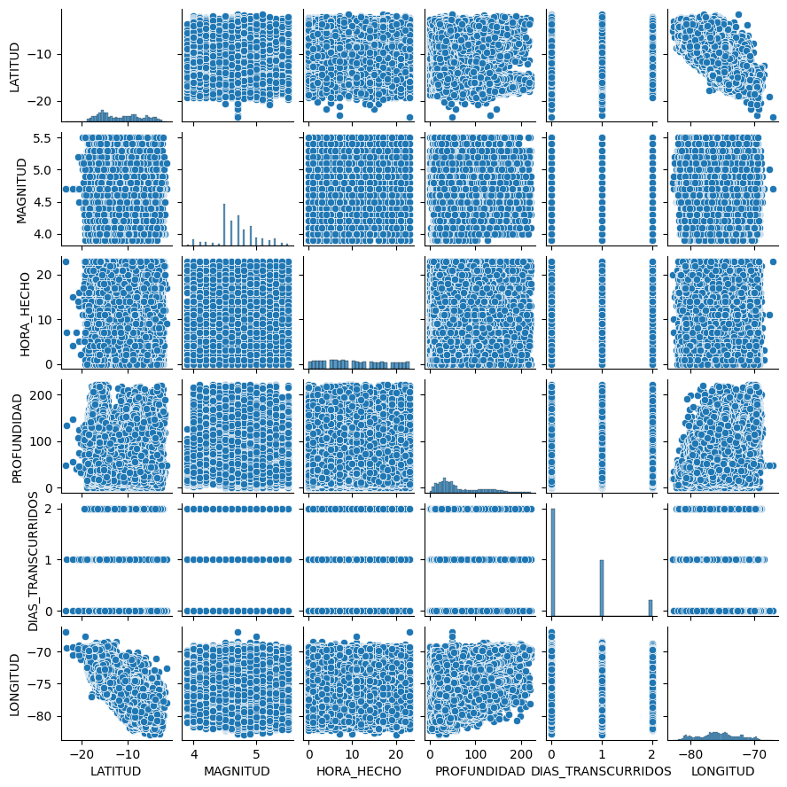

```python
data_medmen = pd.merge(X_medmen, y, left_index = True, right_index = True, how = 'inner')
sns.pairplot(data_medmen, height = 1.5)
```

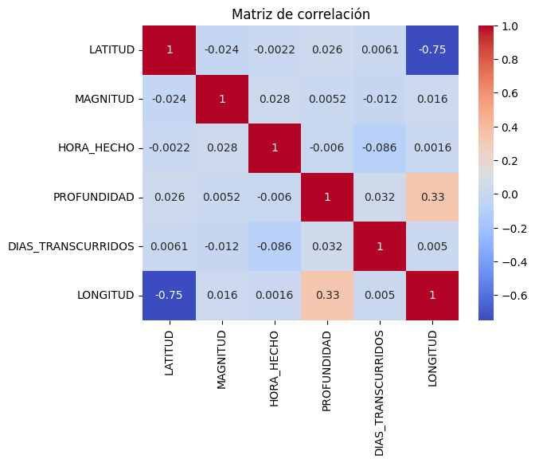

```python
matriz_correlacion(data_medmen)
```

```python
train_test(X_medmen, y)
```

|  | Modelo | R-cuadrado (R2) | Raiz del Error Cuadrático Medio (RMSE) |
| --- | --- | --- | --- |
| 0 | Lineal | 69.222% | 1.728883 |
| 1 | DecisionTree | 73.965% | 1.590102 |
| 2 | RandomForest | 76.937% | 1.496583 |
| 3 | SupportVectorialMachine | 68.804% | 1.740586 |

# **Validación Cruzada (Cross-Validation)**

La validación cruzada es una técnica utilizada en *Machine Learning* para evaluar el desempeño de un modelo. Consiste en dividir el conjunto de datos en partes, entrenar el modelo en una porción de los datos y validarlo en otra. Esto permite medir la capacidad del modelo para generalizar a datos no vistos, reduciendo el riesgo de sobreajuste (*overfitting*) o subajuste (*underfitting*).

```python
# ———Creación de una función para calcular la validacion cruzada———
def validacion_cruzada(X_train, y_train):
  Modelos_base = {'Lineal': LinearRegression(), 'DecisionTree': DecisionTreeRegressor(max_depth=5), 'RandomForest': RandomForestRegressor(n_estimators=100, random_state=123),
                  'SupportVectorialMachine': SVR(kernel='rbf')}
  print(50*'='+'VALIDACIÓN CRUZADA'+50*'=')
  for modelos in Modelos_base:
    vc = cross_val_score(Modelos_base[modelos], X_train, y_train, scoring = 'r2')
    print(f'Para el modelo {modelos}: {vc}. En promedio: {(vc.mean())*100:.3f}%')
  print('='*118)
```

```python
# ———Creación de una función final que contenga R2, RMSE y Validación Cruzada———
def modelo_global_final(X, y):
  Modelos_base = {'Lineal': LinearRegression(), 'DecisionTree': DecisionTreeRegressor(max_depth=5), 'RandomForest': RandomForestRegressor(n_estimators=100, random_state=123),
                  'SupportVectorialMachine': SVR(kernel='rbf')}
  Resultados = []
  Resultados_parciales = train_test(X, y)
  for modelos in Modelos_base:
    vc = cross_val_score(Modelos_base[modelos], X_train, y_train)
    Resultados.append(f'{(vc.mean())*100:.3f}%')
  Resultados_vc = pd.DataFrame(
      data = {'Modelo': ['Lineal','DecisionTree','RandomForest','SupportVectorialMachine'],
              'Validación Cruzada': Resultados}
  )
  Resultados_completos = pd.merge(Resultados_parciales, Resultados_vc, on = 'Modelo')
  return Resultados_completos
```

## Pre-tratamiento de los datos

```python
# ———Datos sin estandarizar———
validacion_cruzada(X_train, y_train)
```

```
==================================================VALIDACIÓN CRUZADA==================================================
Para el modelo Lineal: [0.70712232 0.70435049 0.69929332 0.68729635 0.70969575]. En promedio: 70.155%
Para el modelo DecisionTree: [0.77084193 0.76258005 0.76769654 0.75868664 0.77427663]. En promedio: 76.682%
Para el modelo RandomForest: [0.79719931 0.77897758 0.78368923 0.77254962 0.79093696]. En promedio: 78.467%
Para el modelo SupportVectorialMachine: [0.72561025 0.71405216 0.71925558 0.71982308 0.72326328]. En promedio: 72.040%
======================================================================================================================
```

```python
modelo_global_final(X, y)
```

|  | Modelo | R-cuadrado (R2) | Raiz del Error Cuadrático Medio (RMSE) | Validación Cruzada |
| --- | --- | --- | --- | --- |
| 0 | Lineal | 71.126% | 1.674569 | 70.155% |
| 1 | DecisionTree | 77.080% | 1.491931 | 76.682% |
| 2 | RandomForest | 79.295% | 1.418013 | 78.467% |
| 3 | SupportVectorialMachine | 72.613% | 1.630861 | 72.040% |

```python
# ———Datos estandarizados———
validacion_cruzada(Xs_train, ys_train)
```

```
==================================================VALIDACIÓN CRUZADA==================================================
Para el modelo Lineal: [0.70712232 0.70435049 0.69929332 0.68729635 0.70969575]. En promedio: 70.155%
Para el modelo DecisionTree: [0.77084193 0.76258005 0.76769654 0.75868664 0.77427663]. En promedio: 76.682%
Para el modelo RandomForest: [0.7963962  0.77899681 0.7837719  0.77271109 0.79026427]. En promedio: 78.443%
Para el modelo SupportVectorialMachine: [0.76393398 0.74047247 0.75401166 0.74563078 0.75725974]. En promedio: 75.226%
======================================================================================================================
```

```python
modelo_global_final(X_scal, y_scal)
```

|  | Modelo | R-cuadrado (R2) | Raiz del Error Cuadrático Medio (RMSE) | Validación Cruzada |
| --- | --- | --- | --- | --- |
| 0 | Lineal | 71.126% | 0.540901 | 70.155% |
| 1 | DecisionTree | 77.080% | 0.481907 | 76.682% |
| 2 | RandomForest | 79.307% | 0.457900 | 78.467% |
| 3 | SupportVectorialMachine | 76.390% | 0.489108 | 72.040% |

## Post-tratamiento de los datos

```python
# ———Eliminación de Outliers———
modelo_global_final(X_cleaned1, y_cleaned1)
```

|  | Modelo | R-cuadrado (R2) | Raiz del Error Cuadrático Medio (RMSE) | Validación Cruzada |
| --- | --- | --- | --- | --- |
| 0 | Lineal | 72.214% | 1.600490 | 70.155% |
| 1 | DecisionTree | 76.674% | 1.466420 | 76.682% |
| 2 | RandomForest | 77.221% | 1.449117 | 78.467% |
| 3 | SupportVectorialMachine | 71.972% | 1.607441 | 72.040% |

```python
# ———Winsorización———
modelo_global_final(X_winsorized, y)
```

|  | Modelo | R-cuadrado (R2) | Raiz del Error Cuadrático Medio (RMSE) | Validación Cruzada |
| --- | --- | --- | --- | --- |
| 0 | Lineal | 72.351% | 1.638641 | 70.155% |
| 1 | DecisionTree | 77.029% | 1.493617 | 76.682% |
| 2 | RandomForest | 79.200% | 1.421285 | 78.467% |
| 3 | SupportVectorialMachine | 72.888% | 1.622643 | 72.040% |

```python
# ———Sustitución por media/mediana———
modelo_global_final(X_medmen, y)
```

|  | Modelo | R-cuadrado (R2) | Raiz del Error Cuadrático Medio (RMSE) | Validación Cruzada |
| --- | --- | --- | --- | --- |
| 0 | Lineal | 69.222% | 1.728883 | 70.155% |
| 1 | DecisionTree | 73.965% | 1.590102 | 76.682% |
| 2 | RandomForest | 76.937% | 1.496583 | 78.467% |
| 3 | SupportVectorialMachine | 68.804% | 1.740586 | 72.040% |

# **Conclusiones finales**

- La mayoría de las variables no poseen una alta correlación entre ellas. En gran parte, es muy cercano a cero.
- El tratamiento de los *outliers* no solucionó los bajos valores proporcionados por el R2 y la validación cruzada en los modelos utilizados.
- Por lo general, tanto con los datos estandarizados como no, el R-squared (R2) de cada modelo no supera el 80%. Esto quiere decir que existe un mejor modelo que pueda explicar la variabilidad de la variable dependiente (Y) con respecto a la variable independiente (X).
- La validación cruzada de cada modelo es una medida que abarca el rendimiento del modelo de forma general, mientras que el R2; de forma particular. En mi opinión, un mejor indicador del rendimiento vendría a ser la validación cruzada. En este caso, en varios modelos supera a lo que ofrece el R2; no obstante, sigue siendo menor a 80%. Por lo tanto, hay mejores modelos.

**Fuente de los datos**: https://www.datosabiertos.gob.pe/dataset/cat%C3%A1logo-s%C3%ADsmico-1960-2023-instituto-geof%C3%ADsico-del-per%C3%BA-igp

**Comentarios finales del autor:** En los próximos proyectos, intentaré implementar una mayor diversidad de algoritmos distintos a los vistos aquí.

Muchas gracias por llegar hasta aquí. Un saludo 😃, nos vemos.

```python
# Conversión a formato HTML
!jupyter nbconvert --to html "/content/drive/My Drive/Colab Notebooks/Sismos_1960_2023.ipynb"
```

```
[NbConvertApp] Converting notebook /content/drive/My Drive/Colab Notebooks/Sismos_1960_2023.ipynb to html
[NbConvertApp] WARNING | Alternative text is missing on 18 image(s).
[NbConvertApp] Writing 3868971 bytes to /content/drive/My Drive/Colab Notebooks/Sismos_1960_2023.html
```